# Uppföljning Dalastrategin

# 3 Ett sammanhållet Dalarna

I ett sammanhållet Dalarna finns goda livsmiljöer som skapar en känsla av närhet. Det är ett Dalarna fyllt av engagemang, där människor upplever delaktighet och tillsammans bidrar till en hållbar utveckling. Det är ett inkluderande, jämställt, och jämlikt Dalarna där människor mår bra och där alla ges möjlighet att utvecklas.

Den sociala dimensionen av hållbarhet i det regionala utvecklingsarbetet handlar om att alla människor, utifrån sina behov och förutsättningar, ges likvärdiga möjligheter att delta i samhällsutvecklingen. Ju fler som känner sig delaktiga, desto mer utveckling kan åstadkommas.

## 3.1 Dalfolkets hälsa och trygghet

Friska och trygga människor….

Medellivslängd ⬇

Upplevd hälsa ⬇

Folksjukdomar ⬇

Brott mot person ⬇

Upplevd trygghet ⬇

### Medellivslängd

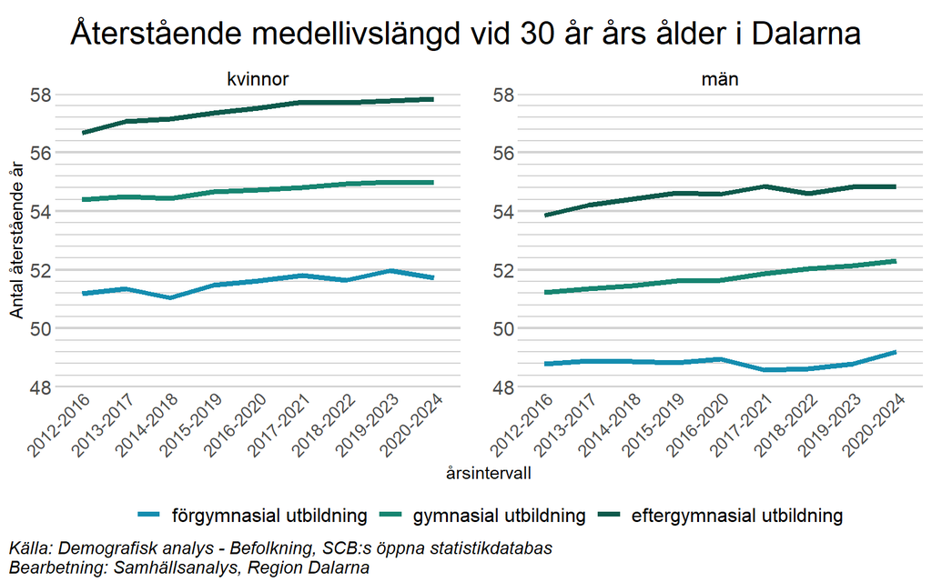

### Upplevd hälsa

Allvarlig psykisk påfrestning efter utbildningsnivå och kön (HLV)

Unga som skattar sin hälsa som mycket eller ganska bra (LUPP)

Andel unga som har svårt att somna i stort sett varje dag eller flera gånger i veckan efter kön, högstadiet och/eller gymnasiet (LUPP)

Andel med lätta eller svåra sömnbesvär, efter utbildning och kön (HLV)

### Folksjukdomar

Hjärtinfarkt – incidenta fall per 100 000 (SoS)

Hypertoni – efter utbildningsnivå och kön (HLV)

Övervikt/obesitas – efter utbildningsnivå och kön (HLV)

Fallskador bland personer 65+, 3-årsm, antal/100 000 inv (SoS)

### Brott mot person

Anmälda misshandelsbrott mot kvinna, inomhus, bekant med offret, antal/100 000 inv, per kommun (BRÅ/SCB)

Anmälda sexualbrott, antal/100 000 inv, per kommun (BRÅ/SCB)

Anmälda våldsbrott, antal/100 000 inv per kommun (BRÅ/SCB)

[figure not shown]

### Upplevd trygghet

Avstår att gå ut ensam av rädsla för att bli överfallen, rånad eller på annat sätt ofredad, efter utbildningsnivå och kön (HLV)

Andel elever som alltid eller ofta känner sig trygga på sociala medier, efter kön (7:e klass och/eller Åk 1 gymnasiet)

Andel elever som tycker att det stämmer helt eller till stor del att rasism förekommer på skolan, efter kön, högstadiet och/eller gymnasiet (LUPP)

## 3.2 Dalfolkets delaktighet, samhällsengagemang och tillit

Valdeltagande/ samhällsengagemang ⬇

Kultur/fritid unga (LOK, kulturskola) ⬇

Tillgång fysiskt: bibliotek, skola, service ⬇

Skola och arbetsliv ⬇

Digital uppkoppling geografi ⬇

Kulturarv ⬇

Mer att läsa finns här:

### Valdeltagande och samhällsengagemang

Ex. diagram över Unga som vill vara med och påverka i frågor som rör kommunen (LUPP)

### Tillit

Tillit till andra människor efter utbildningsnivå och kön (HLV)

Tillit till samhällsfunktioner efter utbildningsnivå och kön (HLV, ny design från och med 2024)

Det är människorna i Dalarna som skapar regionen – alla enskilda individer boende i länet, som också är del av familjer och av andra gemenskaper, organisationer och företag. Människors känsla av sammanhang och delaktighet är centralt för att skapa ett väl fungerande samhälle. För att skapa sammanhang och delaktighet behövs tillit mellan dem som ingår i gemenskapen, och det behövs sätt att hantera osäkerhet som kan uppstå när nya medlemmar inkluderas i en gemenskap. Socialt kapital beskriver det kitt som uppstår när en grupp människor enas kring gemensamma värden, normer och värderingar, det får människor att ha tillit till sina medmänniskor och till det gemensamma. Att den representativa demokratins institutioner, såsom kommuner, region och myndigheter, är väl fungerande och att invånarna har förtroende för dem är centralt för en levande demokrati. En stark tillit till andra underlättar samarbetet mellan människor och viljan och förmågan att bidra med nya idéer till samhällsutvecklingen. Ett samhälle med ett starkt socialt kapital är bättre rustat för att möta förändringar och eventuella kriser.

Indikatorn för tillit mäter andel (%) invånare 16-84 år som i en enkätundersökning har uppgett att de anser sig sakna tillit till andra. Värdet är beräknat som medelvärdet över en fyraårsperiod. Mellan tidsperioden 2004-2007 och 2021-2024 visar det sig att andelen som anser sig sakna tillit har ökat något, från 28 procent till 29 procent. Under intervallet har däremot andelen under perioden 2007 till 2015 varit lägre mellan 23 och 25 procent. Andelen kvinnor som saknar tillit till andra har varit högre än andelen män som saknar tillit till andra fram till ungefär år 2015. Sedan år 2015 är mönstret inte längre entydigt, och det senaste året 2024 uppgav en större andel män, än kvinnor, att de saknade tillit till andra.

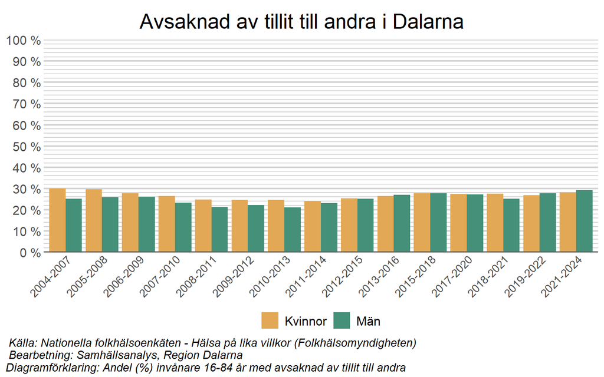

### Kultur/fritid

(LOK, kulturskola)

Mer att läsa finns här.

### Tillgång fysiskt: bibliotek, skola, service

Mer att läsa finns här.

### Skola och arbetsliv

Elever som tycker att det stämmer helt eller till stor del att de trivs med stämningen i skolan (LUPP)

Andel som alltid eller ofta känner sig trygg inför skoldagen efter kön (ELSA) Åk 4, åk 7 eller Åk 1 gymnasiet

## 3.3 Fördelning av inkomster och ekonomiska värden

Sammanfattning.

Ett mönster vi behöver kommentera: ekonomisk situation handlar ju inte bara om lönenivån utan också om kostnader, ex. om boendekostnaderna är lägre så får man ju mer kvar i plånboken, vilket ger förutsättningar för fritid och konsumtion. Hur synliggör vi det?

Jämlikhet/ojämlikhet ⬇

Barn i ekonomisk utsatthet ⬇

Bidragsmottagare ⬇

Sparande och kapital ⬇

Mer att läsa finns här den som önskar.

### Jämlikhet/ojämlikhet

I Dalastrategin lyfts ekonomiska klyftor som en framtidsutmaning för länet. För att redovisa ojämlikheten i inkomstfördelningen används gini-koefficienten. Ett högt värde på koefficienten visar på större inkomstskillnader och därmed större ojämlikhet. Här redovisas ginikoefficienten beräknad genom disponibel inkomst per “konsumtionsenhet” inklusive kapitalvinster. Med konsumtionsenhet menas att det i beräkningen av en individs tillgängliga ekonomiska resurser tas hänsyn till hur hushållet som individen bor i är sammansatt. Det betyder att beräkningen beaktar om personen är ensamboende eller sammanboende och om den har ansvar för minderåriga barn eller inte etc, faktorer som kan minska eller öka individens disponibla inkomst.

**Gini-koefficienten** I Dalarna har ginikoefficienten ökat något från 2011 till 2024, vilket således visar på en ökad ekonomisk ojämlikhet i länet, med en toppnotering 2019. Värt att notera är dock att trenden verkar bruten då ginikoeffiecienten minskade såväl 2023 som 2024, jämfört med åren innan. Ginikoefficienten för länet ligger även under koefficienten för riket för samtliga år förutom 2019, det vill säga i Dalarna är inkomsterna mindre ojämlika än i Sverige som helhet. År 2019 avviker så skarpt från den generella trenden att det årets notering bör betraktas med försiktighet.

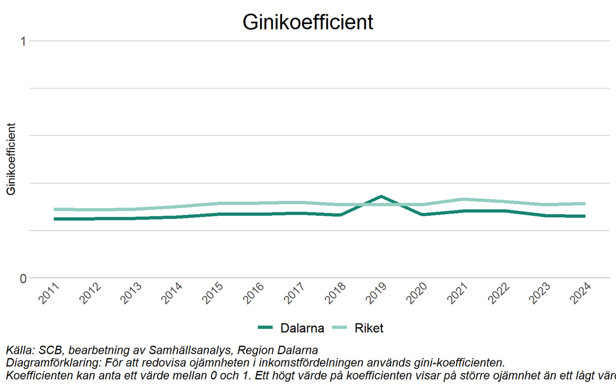

**Inkomstskillnader mellan könen**

En egen inkomst är en av förutsättningarna för ett ekonomiskt självständigt liv. Livsinkomsten påverkar även vilken pension personen kommer att få efter arbetslivet.

För kvinnor och män i Dalarna i arbetsför ålder (20-64 år) är inkomstskillnaderna relativt stora och skillnaderna har hållit i sig över tid. Medianinkomsten för en man i Dalarna var 2024 cirka 427 tusen kronor före skatt, medan en kvinna hade en medianinkomst på ungefär 355 tusen kronor. I den andra figuren nedan syns även en positiv utveckling i form av att den relativa skillnaden i inkomst mellan könen har minskat sedan millennieskiftet. Diagrammet visar att kvinnors medianinkomst har ökat med 118 procent sedan slutet millennieskiftet, medan mäns har ökat med ungefär 99 procent. Det är dock viktigt att notera att figurerna nedan endast redovisar kvinnors och mäns skilda ekonomiska förutsättningar, medan det kan finnas flera förklaringar till skillnaden. En faktor är att kvinnor i högre grad arbetar deltid, och därför kan ha en lägre årsinkomst. Men även yrke, bransch och utbildningsinriktning kan förklara en del av skillnaden.

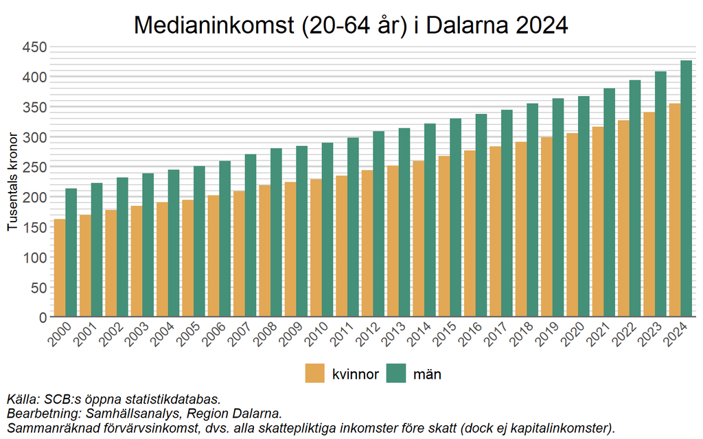

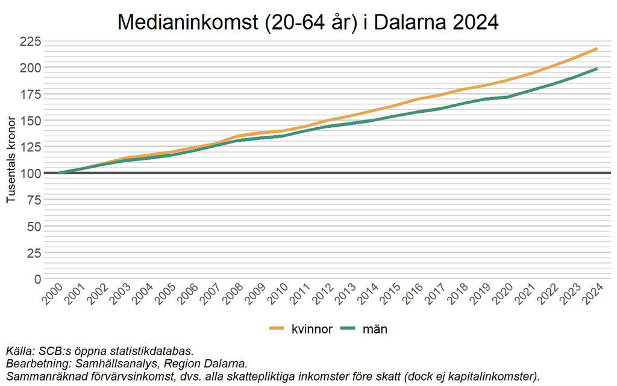

### Barn i ekonomisk utsatthet

Ekonomiska klyftor mellan olika grupper i samhället är en utmaning för både Sverige och Dalarna. Om de socioekonomiska klyftorna blir alltför stora riskerar de att motverka sammanhållning, tillit och trygghet. Det riskerar i sin tur att försvaga demokratin, exempelvis genom systematiska skillnader i valdeltagande, faktiskt eller upplevt inflytande samt delaktighet och engagemang.

Med låg ekonomisk standard menas de hushåll som har en årsinkomst under 60 procent av medianvärdet för hushållens årliga inkomster i Sverige. Andel barn som lever i hushåll med låg ekonomisk standard blir därför ett mått på barns ekonomiska utsatthet i samhället.

I diagrammet nedan kan vi notera att andelen unga (0-19 år) som lever i hushåll med låg ekonomisk standard i Dalarnas län har ökat över mätperioden, vilket är negativt, från 18 procent år 2011 till drygt 20 procent 2024. Viktigt att notera är dock att andelen har minskat tydligt mellan 2019 och 2024, från 23 procent till 20 procent.

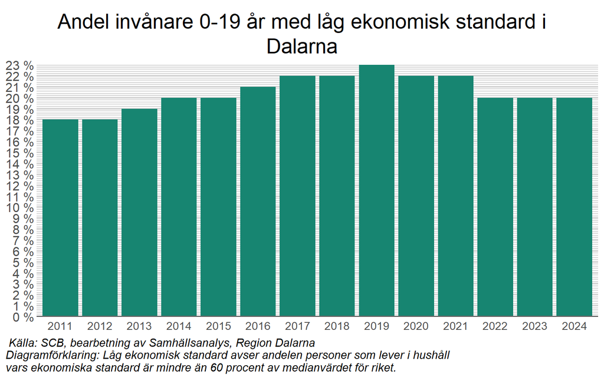

I ett nationellt perspektiv ser vi att endast fem andra län har en högre andel unga som lever i hushåll med låg ekonomisk standard än vad Dalarna har.

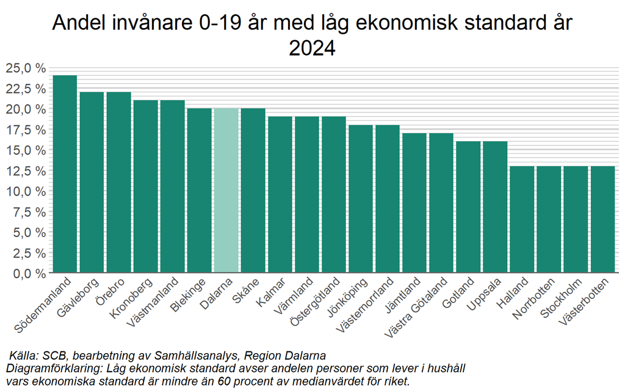

### Bidragsmottagare

De som behöver stöd för att leva ett drägligt liv.

### Sparande och kapital

**Kapitalvinster/förluster**

Kolada

Påverkas av bostadsmarknaden etc.